# Challenger Notebook

The dataset consists of 144 observations of 5 variables consisting of: Flight (name of flight), Date (date of flight), Field (1 if an Oring fails and 0 otherwise), Temp (Temperature in degrees Fahrenheit), Pres (Leak check pressure in psi). Each flight had 6 orings.

```r
orings <- read.csv("Orings.csv")
str(orings)
```

```
'data.frame':   144 obs. of  5 variables:
 $ Flight: Factor w/ 24 levels "1","2","3","41-B",..: 1 1 1 1 1 1 2 2 2 2 ...
 $ Date  : Factor w/ 24 levels "1/12/1986","1/24/1985",..: 14 14 14 14 14 14 8 8 8 8 ...
 $ Field : int  0 0 0 0 0 0 1 0 0 0 ...
 $ Temp  : int  66 66 66 66 66 66 70 70 70 70 ...
 $ Pres  : int  50 50 50 50 50 50 50 50 50 50 ...
```

```r
summary(orings)
```

```
     Flight            Date         Field              Temp            Pres
 1      :  6   1/12/1986 :  6   Min.   :0.00000   Min.   :31.00   Min.   : 50.0
 2      :  6   1/24/1985 :  6   1st Qu.:0.00000   1st Qu.:66.75   1st Qu.: 87.5
 3      :  6   1/28/1986 :  6   Median :0.00000   Median :70.00   Median :200.0
 41-B   :  6   10/3/1985 :  6   Mean   :0.07246   Mean   :67.96   Mean   :154.2
 41-C   :  6   10/30/1985:  6   3rd Qu.:0.00000   3rd Qu.:75.00   3rd Qu.:200.0
 41-D   :  6   10/5/1984 :  6   Max.   :1.00000   Max.   :81.00   Max.   :200.0
 (Other):108   (Other)   :108   NA's   :6
```

The number of orings that have failed out of 6 in each of the flights launched.

```r
tapply(orings$Field,orings$Flight,sum)
```

```
   1    2    3 41-B 41-C 41-D 41-G    5 51-A 51-B 51-C 51-D 51-F 51-G 51-I 51-J    6 61-A 61-B 61-C 61-I    7    8    9
   0    1    0    1    1    1    0    0    0    0    3    0    0    0    0    0    0    2    0    1   NA    0    0    0
```

```r
table(tapply(orings$Field,orings$Flight,sum))
```

```
 0  1  2  3
16  5  1  1
```

Plots of the failures and temperatures with jitter used to randomly perturb points by a small amount to see the points that lie on top of each other better

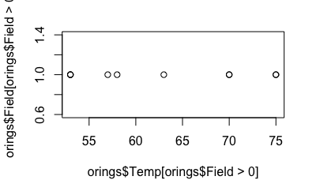

```r
plot(orings$Temp[orings$Field>0],orings$Field[orings$Field>0])
```

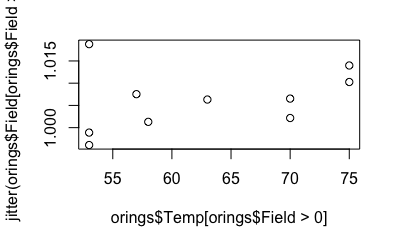

```r
?jitter
plot(orings$Temp[orings$Field>0],jitter(orings$Field[orings$Field>0]))
```

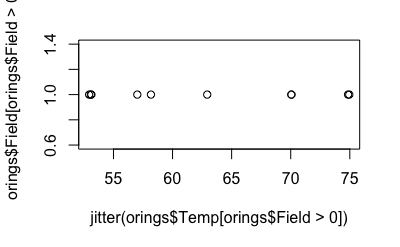

```r
plot(jitter(orings$Temp[orings$Field>0]),orings$Field[orings$Field>0])
```

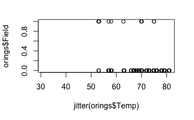

```r
plot(jitter(orings$Temp),orings$Field)
```

The plots of temperature with failures only and the plot of temperatures with both failures and non-failures provides different insights. In the former, there are failures across the range with some more at the extremes. In the second case, it is much clearer that there are lesser failures at higher temperatures. It is believed that analysis of plots such as the first one led the managers to conclude that there was not a significant influence of low temperatures.

Fitting a iinear regression model

```r
model1 <- lm(Field~Temp+Pres,data=orings)
summary(model1)
```

```
Call:
lm(formula = Field ~ Temp + Pres, data = orings)

Residuals:
     Min       1Q   Median       3Q      Max
-0.27680 -0.09548 -0.03457 -0.00874  0.99126

Coefficients:
              Estimate Std. Error t value Pr(>|t|)
(Intercept)  0.7264305  0.2181384   3.330  0.00112 **
Temp        -0.0106657  0.0030704  -3.474  0.00069 ***
Pres         0.0005783  0.0003176   1.821  0.07088 .
---
Signif. codes:  0 '***' 0.001 '**' 0.01 '*' 0.05 '.' 0.1 ' ' 1

Residual standard error: 0.2487 on 135 degrees of freedom
  (6 observations deleted due to missingness)
Multiple R-squared:  0.09941,   Adjusted R-squared:  0.08607
F-statistic: 7.451 on 2 and 135 DF,  p-value: 0.0008524
```

```r
model2 <- lm(Field~Temp,data=orings)
summary(model2)
```

```
Call:
lm(formula = Field ~ Temp, data = orings)

Residuals:
     Min       1Q   Median       3Q      Max
-0.24546 -0.09925 -0.06792 -0.00526  0.98429

Coefficients:
             Estimate Std. Error t value Pr(>|t|)
(Intercept)  0.798942   0.216289   3.694 0.000319 ***
Temp        -0.010443   0.003094  -3.375 0.000961 ***
---
Signif. codes:  0 '***' 0.001 '**' 0.01 '*' 0.05 '.' 0.1 ' ' 1

Residual standard error: 0.2509 on 136 degrees of freedom
  (6 observations deleted due to missingness)
Multiple R-squared:  0.0773,    Adjusted R-squared:  0.07051
F-statistic: 11.39 on 1 and 136 DF,  p-value: 0.0009612
```

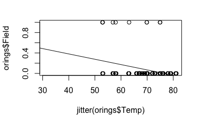

```r
plot(jitter(orings$Temp),orings$Field)
abline(model2)
```

The result indicates that the linear fit is not particularly convincing with a small value of R-squared, though it does identify that temperature has a significant effect and it is a negative impact.

Fitting a logistic regression model: glm() is a generalized linear model that can be used to fit a logistic regression model by choosing family=binomial.

```r
model3 <- glm(Field~Temp+Pres,data=orings,family=binomial)
summary(model3)
```

```
Call:
glm(formula = Field ~ Temp + Pres, family = binomial, data = orings)

Deviance Residuals:
    Min       1Q   Median       3Q      Max
-0.9243  -0.3680  -0.2432  -0.2059   2.8217

Coefficients:
             Estimate Std. Error z value Pr(>|z|)
(Intercept)  3.958071   3.497847   1.132  0.25781
Temp        -0.119355   0.044945  -2.656  0.00792 **
Pres         0.008692   0.007689   1.130  0.25829
---
Signif. codes:  0 '***' 0.001 '**' 0.01 '*' 0.05 '.' 0.1 ' ' 1

(Dispersion parameter for binomial family taken to be 1)

    Null deviance: 71.751  on 137  degrees of freedom
Residual deviance: 60.470  on 135  degrees of freedom
  (6 observations deleted due to missingness)
AIC: 66.47

Number of Fisher Scoring iterations: 6
```

```r
model4 <- glm(Field~Temp,data=orings,family=binomial)
summary(model4)
```

```
Call:
glm(formula = Field ~ Temp, family = binomial, data = orings)

Deviance Residuals:
    Min       1Q   Median       3Q      Max
-0.9155  -0.3770  -0.3075  -0.2036   2.7387

Coefficients:
            Estimate Std. Error z value Pr(>|z|)
(Intercept)  6.75183    2.97991   2.266  0.02346 *
Temp        -0.13971    0.04647  -3.007  0.00264 **
---
Signif. codes:  0 '***' 0.001 '**' 0.01 '*' 0.05 '.' 0.1 ' ' 1

(Dispersion parameter for binomial family taken to be 1)

    Null deviance: 71.751  on 137  degrees of freedom
Residual deviance: 62.083  on 136  degrees of freedom
  (6 observations deleted due to missingness)
AIC: 66.083

Number of Fisher Scoring iterations: 6
```

Model 3 describes P(Fail=1) = exp(3.95-0.119Temp+0.008Pres)/(1+exp(3.95-0.119Temp+0.008Pres)). The result indicates that Temp is significant at the 5% level. Model 4 has a fit given by P(Fail=1) = exp(6.75-0.1397Temp)/(1+exp(6.75-0.1397Temp)). In terms of AIC, Model 4 is preferred to Model 3. We drop the pressure variable in this example.

Prediction and plots

```r
predict(model4,newdata=orings[144,])
```

```
     144
2.420837
```

```r
predict(model4,newdata=orings[144,],type="response")
```

```
      144
0.9184025
```

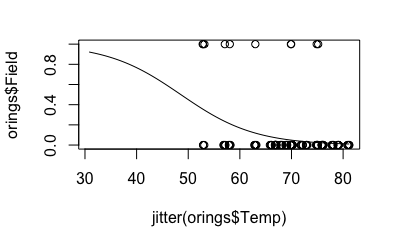

```r
plot(jitter(orings$Temp),orings$Field)
?curve
curve(exp(6.75-0.139*x)/(1+exp(6.75-0.139*x)),add=T)
```

The predicted probability of failure under the model is 0.918.

Developing a predictive rule (classifier) and tabulating confusion matrices. Here we are still evaluating this with the training data. Typically we will use a test data to check on the results.

```r
Pred <- predict(model4,newdata=orings,type="response")
table(Pred[1:138]>0.5,orings$Field[1:138])
```

```
          0   1
  FALSE 128  10
```

```r
table(Pred[1:138]>0.25,orings$Field[1:138])
```

```
          0   1
  FALSE 125   7
  TRUE    3   3
```

```r
table(Pred[1:138]>0.2,orings$Field[1:138])
```

```
          0   1
  FALSE 115   5
  TRUE   13   5
```

The ROCR package is useful for visualizing the performance of classifier. The prediction function transforms the data to a standardized format and the performance function is used to do all kinds of prediction evaluations.

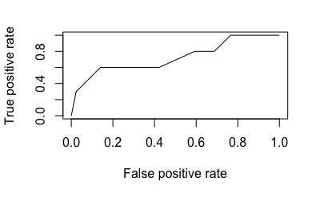

```r
#install.packages("ROCR")
library(ROCR)
ROCRpred <- prediction(Pred[1:138],orings$Field[1:138])
ROCRperf <- performance(ROCRpred,x.measure="fpr",measure="tpr")
plot(ROCRperf)
```

```r
performance(ROCRpred,measure="auc")
```

```
An object of class "performance"
Slot "x.name":
[1] "None"

Slot "y.name":
[1] "Area under the ROC curve"

Slot "alpha.name":
[1] "none"

Slot "x.values":
list()

Slot "y.values":
[[1]]
[1] 0.725


Slot "alpha.values":
list()
```

The AUC for this example is 0.725.